# Conclusions of this Project

Note I did not stratify the dataset as nearly 80% of all commands were 0 and 2. Both CNNs (trained on 0.9x0.8~75% or 22.5k of the 31.4k images captured) failed to generalise well; achieving only 47% and 48% CA on test images. The 1st CNN is disregarded; failing to even learn the training examples (51% compared with 93% for the other). However, they both attained poor rewards and only made the correct action 30% of occasions (as advised by heuristic). The MLP (trained on 0.8x0.8 ~ 64% or 161k of the total 252k states captured), generalised extremely well, and the decision tree and KNN (k=5) likewise, with test CAs of 99%, 87% and 85%. All three obtained great rewards, but the MLP was by far the best algorithm making the heuristic-advised move 98.6% of the time. Perhaps the disparity between the image and state models is that the state models were trained on 5 times as many examples, and could generalise much better as high-level representations made it easier to draw connections between similar events due to capturing universal information about position of the Lundar-Lander in only 8 numbers (vs 1x64x64=4096). Moreover I didn't stop the CNNs when their training and validation accuracies diverged, which worsened generalisation. The state models were also (66secs_per_epoch/3secs_per_epoch) 22 times quicker to train. The DQN agent was trained on 2mil examples (or steps) which took much longer than the other models (6.8 and 50 times more than the Atari CNN and MLP respectively). Its rewards were reasonably high. Since we never run out of training examples the DQN could challenge the MLP if it played long enough, so long as the agent keeps improving its policy (which is thusfar the case – see the mean reward per step chart). However, the MLP is considered to have already "solved" the Lunar Lander problem by averaging over 200pts per episode. Thus, the lesson may be that with the right high-level representations in a small state-space problem, classifiers on expert moves can perform accurately and more efficiently than RL algorithms. However, usually most of those conditions are not met.

# Some Comparisons

## Imports

```python
import os
import cv2
import random
import numpy as np
import pandas as pd
import pickle

import matplotlib.pyplot as plt
%matplotlib inline
from matplotlib import ticker
import seaborn as sns

from sklearn.model_selection import train_test_split
from sklearn import metrics
from imblearn.under_sampling import RandomUnderSampler
from sklearn.utils import shuffle

import keras
from keras.models import Sequential
from keras.layers import Input, Dropout, Flatten, Conv2D, MaxPooling2D, Dense, Activation
from keras.optimizers import RMSprop, adam
from keras.utils import np_utils
```

### Load Results

Loads rewards and actions of each model.

```python
with open('states.pckl','rb') as f:
    loaded = pickle.load(f)
f.close()

res_state1 = loaded[0]
res_state2 = loaded[1]
res_state3 = loaded[2]
act_state1 = loaded[3]
act_state2 = loaded[4]
act_state3 = loaded[5]

with open('dqn.pckl','rb') as f:
    loaded2 = pickle.load(f)
f.close()

res_dqn = loaded2[0]
act_dqn = loaded2[1]

with open('results_and_actions.pckl','rb') as f:
    loaded3 = pickle.load(f)
f.close()

res_image1 = loaded3[0]
res_image2 = loaded3[1]
act_image1 = loaded3[2]
act_image2 = loaded3[3]
```

```python
#res_image1 = np.ndarray.tolist(res_image1)
#res_image1 = [item for sublist in res_image1 for item in sublist]
res_image2 = np.ndarray.tolist(res_image2)
res_image2 = [item for sublist in res_image2 for item in sublist]
res_state1 = np.ndarray.tolist(res_state1)
res_state1 = [item for sublist in res_state1 for item in sublist]
res_state2 = np.ndarray.tolist(res_state2)
res_state2 = [item for sublist in res_state2 for item in sublist]
res_state3 = np.ndarray.tolist(res_state3)
res_state3 = [item for sublist in res_state3 for item in sublist]
res_dqn = np.ndarray.tolist(res_dqn)
res_dqn = [item for sublist in res_dqn for item in sublist]
```

### Distribution of Episode Rewards

```
Text(0.5,1,'DQN Rewards Per Episode of My CNN')
```

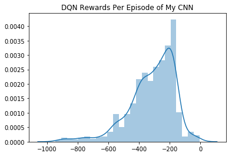

```python
sns.distplot(res_image1).set_title('DQN Rewards Per Episode of My CNN')
```

```
Text(0.5,1,'DQN Rewards Per Episode of Atari CNN')
```

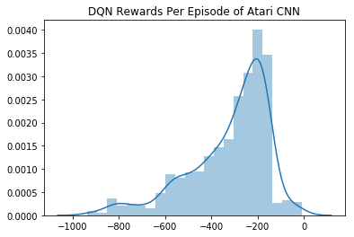

```python
sns.distplot(res_image2).set_title('DQN Rewards Per Episode of Atari CNN')
```

```
Text(0.5,1,'DQN Rewards Per Episode of MLP')
```

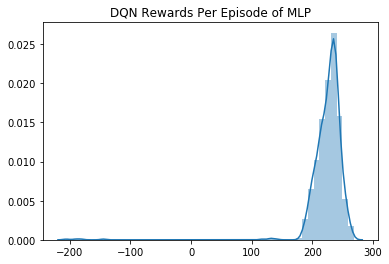

```python
sns.distplot(res_state1).set_title('DQN Rewards Per Episode of MLP')
```

```
Text(0.5,1,'DQN Rewards Per Episode of Decision Tree')
```

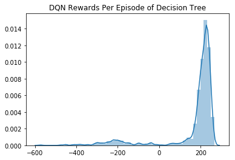

```python
sns.distplot(res_state2).set_title('DQN Rewards Per Episode of Decision Tree')
```

```
Text(0.5,1,'DQN Rewards Per Episode of KNN')
```

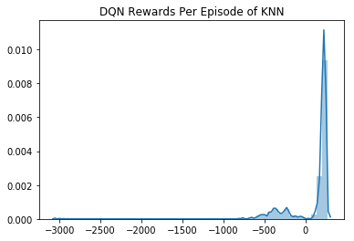

```python
sns.distplot(res_state3).set_title('DQN Rewards Per Episode of KNN')
```

```
Text(0.5,1,'DQN Rewards Per Episode of DQN')
```

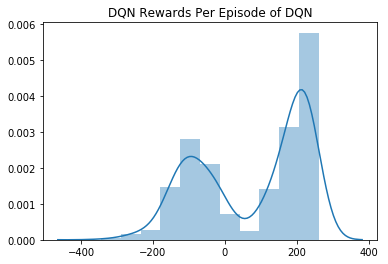

```python
sns.distplot(dqn_test['episode_reward']).set_title('DQN Rewards Per Episode of DQN')
```

```python
act_state1 = pd.DataFrame(act_state1)
act_state2 = pd.DataFrame(act_state2)
act_state3 = pd.DataFrame(act_state3)
act_image1 = pd.DataFrame(act_image1)
act_image2 = pd.DataFrame(act_image2)
act_dqn = pd.DataFrame(act_dqn)
```

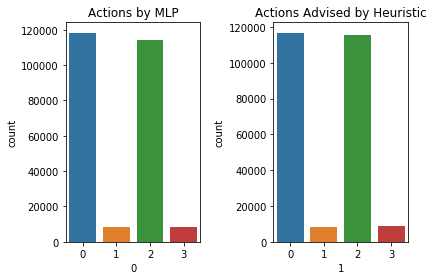

```python
actions = act_state1
fig, ax = plt.subplots(1,2)
sns.countplot(actions[:][0], ax=ax[0]).set_title('Actions by MLP')
sns.countplot(actions[:][1], ax=ax[1]).set_title('Actions Advised by Heuristic')
fig.tight_layout()
fig.show()
```

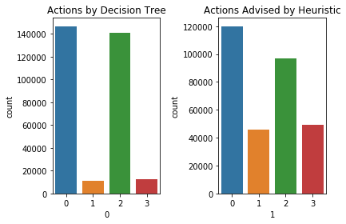

```python
actions = act_state2
fig, ax = plt.subplots(1,2)
sns.countplot(actions[:][0], ax=ax[0]).set_title('Actions by Decision Tree')
sns.countplot(actions[:][1], ax=ax[1]).set_title('Actions Advised by Heuristic')
fig.tight_layout()
fig.show()
```

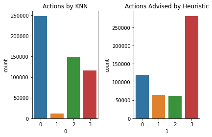

```python
actions = act_state3
fig, ax = plt.subplots(1,2)
sns.countplot(actions[:][0], ax=ax[0]).set_title('Actions by KNN')
sns.countplot(actions[:][1], ax=ax[1]).set_title('Actions Advised by Heuristic')
fig.tight_layout()
fig.show()
```

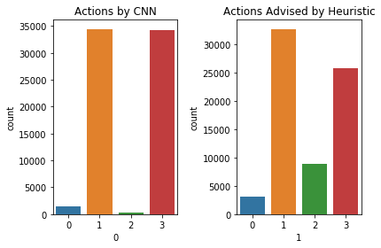

```python
actions = act_image1
fig, ax = plt.subplots(1,2)
sns.countplot(actions[:][0], ax=ax[0]).set_title('Actions by CNN')
sns.countplot(actions[:][1], ax=ax[1]).set_title('Actions Advised by Heuristic')
fig.tight_layout()
fig.show()
```

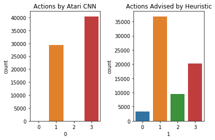

```python
actions = act_image2
fig, ax = plt.subplots(1,2)
sns.countplot(actions[:][0], ax=ax[0]).set_title('Actions by Atari CNN')
sns.countplot(actions[:][1], ax=ax[1]).set_title('Actions Advised by Heuristic')
fig.tight_layout()
fig.show()
```

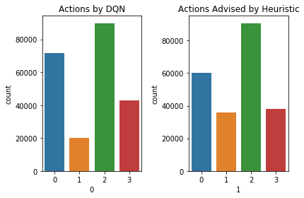

```python
actions = act_dqn
fig, ax = plt.subplots(1,2)
sns.countplot(actions[:][0], ax=ax[0]).set_title('Actions by DQN')
sns.countplot(actions[:][1], ax=ax[1]).set_title('Actions Advised by Heuristic')
fig.tight_layout()
fig.show()
```

```python
print("Average Reward Per Episode for MLP: ",sum(res_state1)/1000, "\nAverage Reward Per Episode for Decision Tree: ",\
      sum(res_state2)/1000, "\nAverage Reward Per Episode for KNN: ", sum(res_state3)/1000, \
      "\nAverage Reward Per Episode for My CNN: ", sum(res_image1)/1000, \
     "\nAverage Reward Per Episode for Atari CNN: ", sum(res_image2)/1000, \
     "\nAverage Reward Per Episode for DQN: ", sum(dqn_test['episode_reward'])/1000, "\n")

print("Time to Train MLP: ",10, "mins - 3 secs per epoch\nTime to Train Decision Tree: ",\
      1, "min\nTime to Train KNN: ", 1, \
      "min\nTime to Train My CNN: ", 147, \
     "mins - 126 secs per epoch\nTime to Train Atari CNN: ", 77, \
     "mins - 66 secs per epoch\nTime to Train DQN: ", 526, "mins\n")

print("Average Reward Per Episode Per Minute Trained for MLP: ",sum(res_state1)/(1000*10), \
      "\nAverage Reward Per Episode Per Minute Trained for Decision Tree: ",\
      sum(res_state2)/1000*1, "\nAverage Reward Per Episode Per Minute Trained for KNN: ", sum(res_state3)/1000*1, \
      "\nAverage Reward Per Episode Per Minute Trained for My CNN: ", sum(res_image1)/(1000*147), \
     "\nAverage Reward Per Episode Per Minute Trained for Atari CNN: ", sum(res_image2)/(1000*77), \
     "\nAverage Reward Per Episode Per Minute Trained for DQN: ", sum(dqn_test['episode_reward'])/(1000*526), "\n")

accuracy = round(100*metrics.accuracy_score(np.array(act_state1[:][1]), np.array(act_state1[:][0])),2) # , normalize=True, sample_weight=None
print("Accuracy of actions by MLP compared to heuristic: " +  str(accuracy)+ "%")
accuracy2 = round(100*metrics.accuracy_score(np.array(act_state2[:][1]), np.array(act_state2[:][0])),2) # , normalize=True, sample_weight=None
print("Accuracy of actions by Decision Tree compared to heuristic: " +  str(accuracy2)+ "%")
accuracy3 = round(100*metrics.accuracy_score(np.array(act_state3[:][1]), np.array(act_state3[:][0])),2) # , normalize=True, sample_weight=None
print("Accuracy of actions by KNN compared to heuristic: " +  str(accuracy3) + "%")

accuracy4 = round(100*metrics.accuracy_score(np.array(act_image1[:][1]), np.array(act_image1[:][0])),2) # , normalize=True, sample_weight=None
print("Accuracy of actions by My CNN compared to heuristic: " +  str(accuracy4)+ "%")
accuracy5 = round(100*metrics.accuracy_score(np.array(act_image2[:][1]), np.array(act_image2[:][0])),2) # , normalize=True, sample_weight=None
print("Accuracy of actions by Atari CNN compared to heuristic: " +  str(accuracy5)+ "%")
```

```
Average Reward Per Episode for MLP:  224.93340490862494
Average Reward Per Episode for Decision Tree:  168.38352942541692
Average Reward Per Episode for KNN:  103.28250083443358
Average Reward Per Episode for My CNN:  -316.78229911725714
Average Reward Per Episode for Atari CNN:  -321.7027657248342
Average Reward Per Episode for DQN:  77.27019831736152

Time to Train MLP:  10 mins - 3 secs per epoch
Time to Train Decision Tree:  1 min
Time to Train KNN:  1 min
Time to Train My CNN:  147 mins - 126 secs per epoch
Time to Train Atari CNN:  77 mins - 66 secs per epoch
Time to Train DQN:  526 mins

Average Reward Per Episode Per Minute Trained for MLP:  22.493340490862494
Average Reward Per Episode Per Minute Trained for Decision Tree:  168.38352942541692
Average Reward Per Episode Per Minute Trained for KNN:  103.28250083443358
Average Reward Per Episode Per Minute Trained for My CNN:  -2.1549816266480075
Average Reward Per Episode Per Minute Trained for Atari CNN:  -4.177957996426418
Average Reward Per Episode Per Minute Trained for DQN:  0.14690151771361504

Accuracy of actions by MLP compared to heuristic: 98.6%
Accuracy of actions by Decision Tree compared to heuristic: 66.43%
Accuracy of actions by KNN compared to heuristic: 52.7%
Accuracy of actions by My CNN compared to heuristic: 29.73%
Accuracy of actions by Atari CNN compared to heuristic: 29.13%
```

```python
accuracy6 = round(100*metrics.accuracy_score(np.array(act_dqn[:][1]), np.array(act_dqn[:][0])),2) # , normalize=True, sample_weight=None
print("Accuracy of actions by DQN compared to heuristic: " +  str(accuracy6)+ "%")
```

```
Accuracy of actions by DQN compared to heuristic: 30.61%
```

Note that I accidentally overwrote my dqn training history pickle file so I copied the print output into a csv to read in instead of re-running.

```python
dqn_train = pd.read_csv("C:/Users/Luke/Documents/UCD/AML/Labs/Assignment 2/Everything/DQN_Training_Results.csv")
dqn_train = pd.DataFrame(data=dqn_train)
```

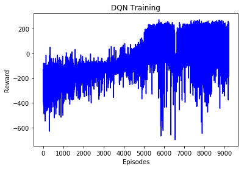

```python
plt.xlabel('Episodes')
plt.ylabel('Reward')
plt.plot(dqn_train['episode reward'], 'blue')
plt.xticks(range(0,len(dqn_train['episode reward']))[0::1000])
plt.title("DQN Training")
plt.show()
```

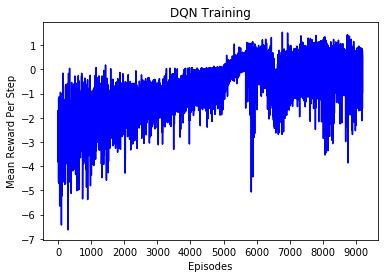

```python
plt.xlabel('Episodes')
plt.ylabel('Mean Reward Per Step')
plt.plot(dqn_train['mean reward'], 'blue')
plt.xticks(range(0,len(dqn_train['mean reward']))[0::1000])
plt.title("DQN Training")
plt.show()
```

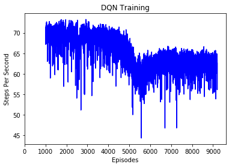

```python
plt.xlabel('Episodes')
plt.ylabel('Steps Per Second')
plt.plot(dqn_train['steps'][1000:]/dqn_train['duration (seconds)'][1000:], 'blue')
plt.xticks(range(0,len(dqn_train['mean reward']))[0::1000])
plt.title("DQN Training")
plt.show()
```

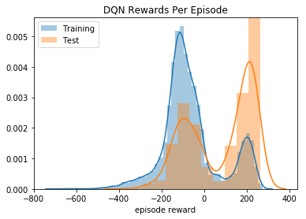

```python
sns.distplot(dqn_train['episode reward'], label = 'Training').set_title('DQN Rewards Per Episode')
sns.distplot(dqn_test['episode_reward'], label = 'Test')
plt.legend()
```